# ODD_Analysis

Batur Usta

19 KasÄ±m 2018

## Exploration and Wrangling

In order to do a proper analysis, I should look at the structure of the dataset. The dataset contains brand by brand retail sales of automobiles and commercial vehicles over a monthly basis in Turkey.

```
## Classes 'tbl_df', 'tbl' and 'data.frame':    1490 obs. of  12 variables:
##  $ brand_name : chr  "ALFA ROMEO" "ASTON MARTIN" "AUDI" "BENTLEY" ...
##  $ auto_dom   : num  0 0 0 0 0 0 0 0 0 632 ...
##  $ auto_imp   : num  13 2 350 0 158 ...
##  $ auto_total : num  13 2 350 0 158 ...
##  $ comm_dom   : num  0 0 0 0 0 0 0 0 0 789 ...
##  $ comm_imp   : num  0 0 0 0 0 197 319 0 0 199 ...
##  $ comm_total : num  0 0 0 0 0 197 319 0 0 988 ...
##  $ total_dom  : num  0 0 0 0 0 ...
##  $ total_imp  : num  13 2 350 0 158 331 1460 9 3 256 ...
##  $ total_total: num  13 2 350 0 158 ...
##  $ year       : num  2018 2018 2018 2018 2018 ...
##  $ month      : num  9 9 9 9 9 9 9 9 9 9 ...
```

Here’s a brief explanation of variables: -brand_name : Name of the automobile brand. -auto_dom : Amount of sales of domestic product automobiles for the given month. -auto_imp : Amount of sales of imported automobiles for the given month. -auto_total : Amount of total sales of automobiles for the given month. -comm_dom : Amount of sales of domestic product commercial vehicles for the given month. -comm_imp : Amount of sales of imported commercial vehicles for the given month. -comm_total : Amount of total sales of commercial vehicles for the given month. -total_dom : Amount of sales of all domestic product vehicles for the given month. -total_imp : Amount of sales of all imported vehicles for the given month. -total_total: Amount of total sales of all vehicles for the given month. -year : Year -month : Month

And, this is how the dataset looks:

```
## # A tibble: 6 x 12
##   brand_name auto_dom auto_imp auto_total comm_dom comm_imp comm_total
##   <chr>         <dbl>    <dbl>      <dbl>    <dbl>    <dbl>      <dbl>
## 1 ALFA ROMEO        0       13         13        0        0          0
## 2 ASTON MAR~        0        2          2        0        0          0
## 3 AUDI              0      350        350        0        0          0
## 4 BENTLEY           0        0          0        0        0          0
## 5 BMW               0      158        158        0        0          0
## 6 CITROEN           0      134        134        0      197        197
## # ... with 5 more variables: total_dom <dbl>, total_imp <dbl>,
## #   total_total <dbl>, year <dbl>, month <dbl>
```

```
## # A tibble: 6 x 12
##   brand_name auto_dom auto_imp auto_total comm_dom comm_imp comm_total
##   <chr>         <dbl>    <dbl>      <dbl>    <dbl>    <dbl>      <dbl>
## 1 SSANGYONG         0       19         19        0        3          3
## 2 TATA              0        0          0        0        9          9
## 3 TOYOTA         1298      149       1447        0       34         34
## 4 VOLKSWAGEN        0     2792       2792        0     1736       1736
## 5 VOLVO             0      187        187        0        0          0
## 6 TOPLAM:        7375    15983      23358     4815     4540       9355
## # ... with 5 more variables: total_dom <dbl>, total_imp <dbl>,
## #   total_total <dbl>, year <dbl>, month <dbl>
```

The TOPLAM: row contains total amount of a certain month, since this datased is formed by fusing a number of datasets, there should be multiple TOPLAM: rows. I can do that myself so there is no need for such columns to exist. Let’s check for more irregularities in brand_name column

```r
#Drop "TOPLAM:" row
df <- subset(df, brand_name != "TOPLAM:")
#Check for any more irregularities.
#unique(df$brand_name) This prints in a weird format in html, so I'm commenting it out.
```

We’ll need to delete the invalid row that contains a disclaimer. Also, there are two Aston Martin columns. Wonder if there are any more NA’s or invalid rows?

```r
df <- subset(df, brand_name != df$brand_name[which(nchar(df$brand_name)> 20)])
df$brand_name <- str_replace(df$brand_name, "ASTON MARTİN", "ASTON MARTIN")
#Look for NA's
which(is.na(df$brand_name))
```

```
## integer(0)
```

Now the dataset is mostly tidy, I will make one more change, which will be merging year and month columns into one date column in Date format, it will make date based analysis easier.

```r
#Forming the date column in Date format.
df$date <- paste(df$year,df$month,"01")
df$date <- as.Date(df$date, "%Y %m %d")
#Let's drop year and month columns.
df$year <- NULL
df$month <- NULL
```

## Analysis

Let’s start off with a simple graph, yearly total sales.

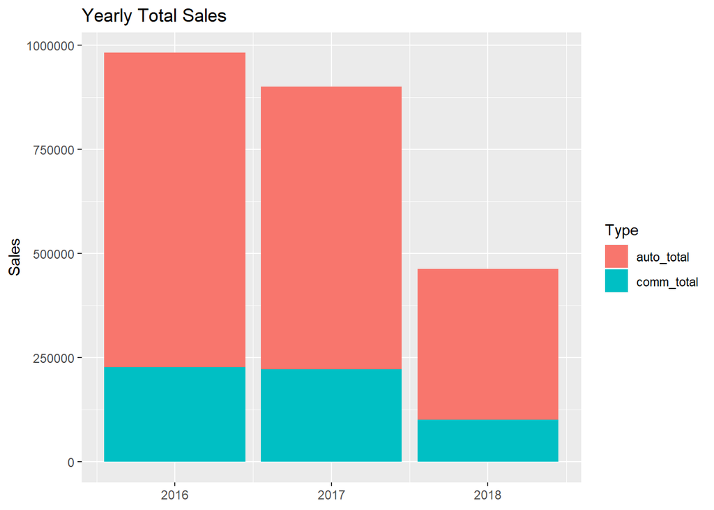

```r
yearly <- df %>%
  select(auto_total, comm_total, date) %>%
  group_by(year=year(date)) %>%
  summarize(auto_total = sum(auto_total), comm_total=sum(comm_total)) %>%
  gather(Type, Sales, -year)
#Plot Bar Graph
ggplot(data=yearly, aes(x=year, y=Sales, fill=Type))+
  geom_col()+
  labs(title="Yearly Total Sales", x=NULL)
```

There is a slight drop in sales in 2017. If the sales were equally distributed troughout the year, I would be able to say that sales in 2018 will be much worse. But before coming to such conclusion, I should check how were the car sales in the last quarter of the year, so that I may predict an outcome for 2018.

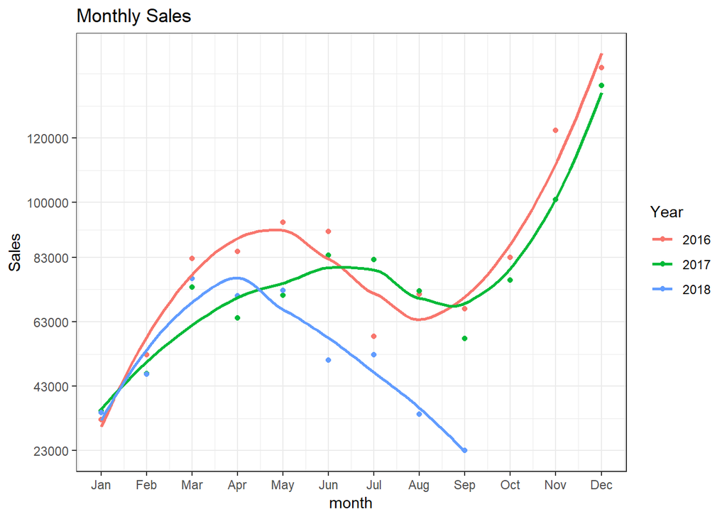

```r
#Create m_sales
m_sales <- df %>%
  select(total_total, date) %>%
  group_by(year=year(date), month=month(date)) %>%
  summarize(total=sum(total_total))
#Plot Monthly Sales
ggplot(data=m_sales, aes(x=month, y=total, group=year, color=as.factor(year)))+
  geom_point()+
  geom_smooth(se=FALSE)+
  scale_y_continuous(breaks=signif(seq(min(m_sales$total),max(m_sales$total), 20000), digits=2))+
  scale_x_continuous(breaks=c(1:12), labels=unique(month.abb[m_sales$month]))+
  labs(title="Monthly Sales", color="Year", y="Sales")+
  theme_bw()
```

It appears that car sales skyrocket in the last quarter. 2018 shows a drastic drop in sales but there is a possibility that total sales will catch up to previous years by the end of the year. Next aspect I want to explore is the distribution of sales of vehicles by brand.

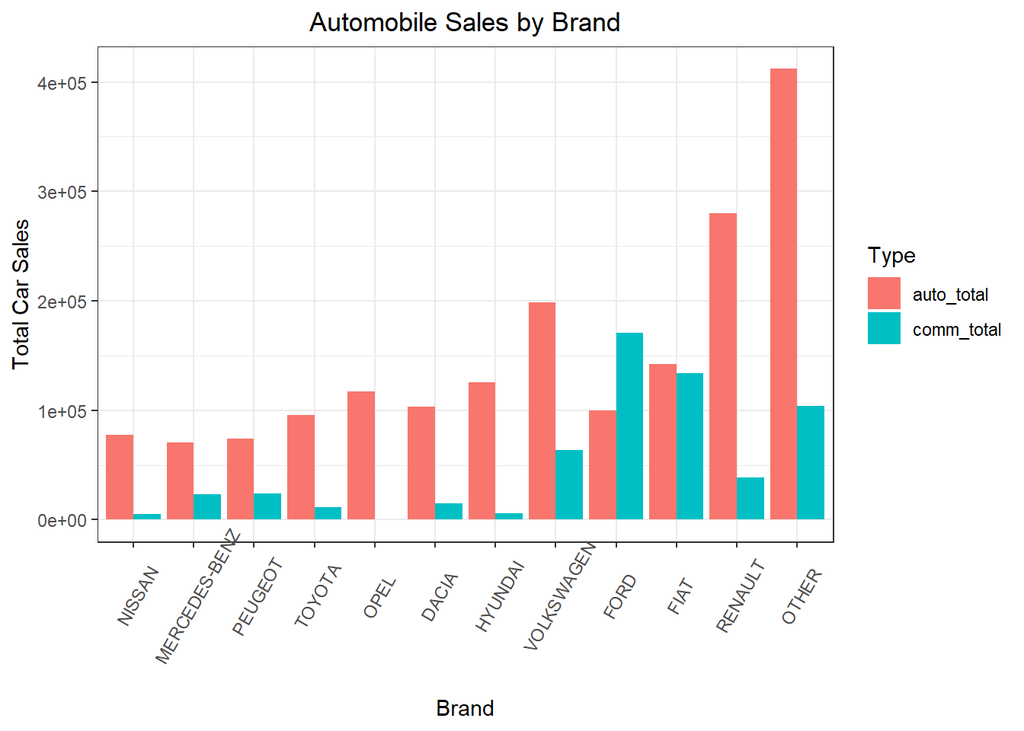

```r
#Restructure the database for brand oriented analysis. Separate Commercial and Automobiles.
bar <- df %>%
  group_by(brand_name) %>%
  select(brand_name, auto_total, comm_total) %>%
  summarize(auto_total=sum(auto_total), comm_total=sum(comm_total)) %>%
  arrange(desc(auto_total))
auto_bar <- bar %>%
  filter(auto_total>cumsum(auto_total)*0.05) %>%
  add_row(brand_name="OTHER", auto_total= (bar %>%
  filter(auto_total<cumsum(auto_total)*0.05)%>%
  summarize(t=sum(auto_total)))$t[1], comm_total=(bar %>%    filter(comm_total<cumsum(comm_total)*0.05)%>%summarize(t=sum(comm_total)))$t[1])%>%
  gather(Type, Sales, -brand_name)

#Plot Bar charts
ggplot(auto_bar, aes(x=reorder(brand_name, Sales), y=Sales, fill=Type))+
  theme_bw()+
  geom_bar(stat="identity", position="dodge")+
  labs(title="Automobile Sales by Brand", y="Total Car Sales", x="Brand")+
  theme(plot.title = element_text(hjust=0.5),
        axis.text.x = element_text(angle=60, vjust=0.7))
```

Renault, Volkswagen, Fiat and Hyundai are the popular brands for automobiles, Renault being the most popular. In commercial vehicles, Renault loses the lead to Ford while Fiat coming next.